# R Notebook

## Density term

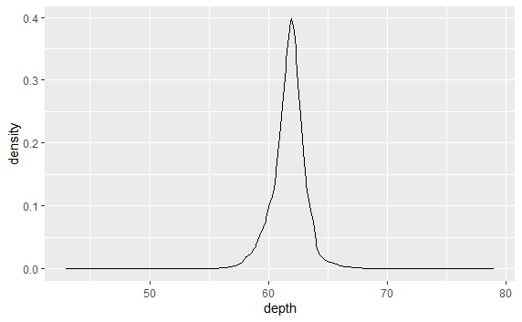

```r
library(ggplot2)
diamonds |> ggplot(aes(x = depth)) + geom_density()
```

## Adding color to the path drawn

to add the color to the path drawn alone, add the color argument in the geom_density funtion, NOT INSIDE THE AES FUNCTION

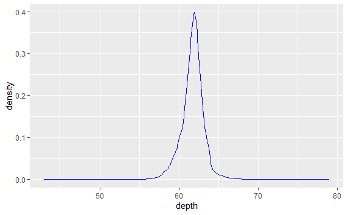

```r
diamonds |> ggplot(aes(x = depth)) + geom_density(color = "blue")
```

## Adding fill

to add the fill color inside the path drawn, add the fill argument in the geom_density function, NOT INSIDE THE AES FUNCTION

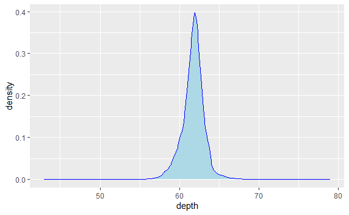

```r
diamonds |> ggplot(aes(x = depth)) + geom_density(color = "blue", fill = "lightblue")
```

## Adding alpha (opacity)

to add the alpha which is how intense the color the look, add the ‘alpha’ argument inside the geom_density function ‘NOT THE AES FUNCTION’

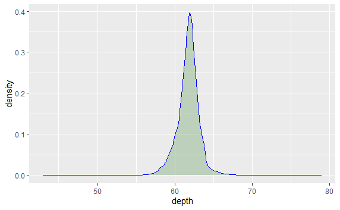

```r
diamonds |> ggplot(aes(x = depth)) + geom_density(color = "blue", fill = "darkgreen", alpha = .2)
```

## Adding multiple density plot based on a second var

to add multiple density plot based on another variable pass the variable to the colour argument **IN THE AES() FUNCTION**

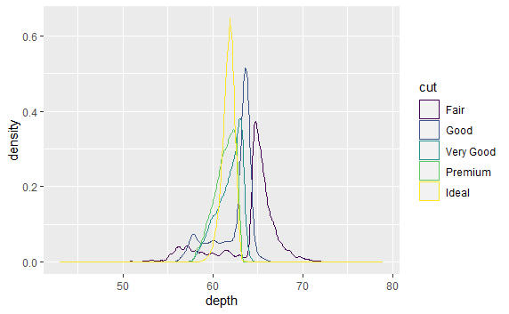

```r
diamonds |> ggplot(aes(x = depth)) + geom_density(aes(color = cut))
```

## Adding color to all density

same way to fill them map the variable to fill **IN THE AES() FUNCTION**

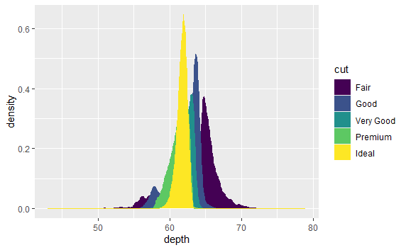

```r
diamonds |> ggplot(aes(x = depth)) + geom_density(aes(color = cut, fill = cut))
```

## Adding alpha to every density

to do this you only need to map the color variable to the alpha too **IN THE AES() FUNCTION**

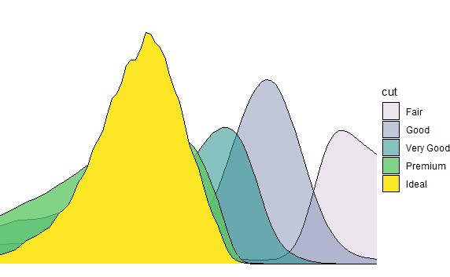

```r
diamonds |> ggplot(aes(x = depth)) + geom_density(aes(fill = cut, alpha = cut)) + coord_cartesian(xlim = c(60, 65), ylim = c(0,.7)) + theme_void()
```

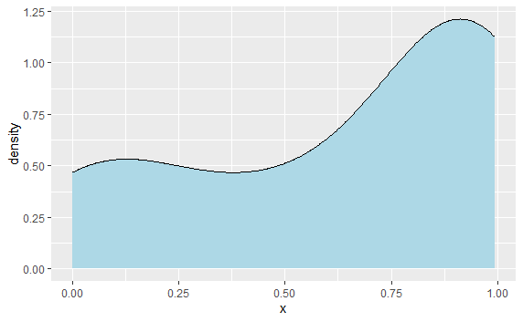

```r
pchisq(q = 0:20, df = 7) -> chi
d <- data.frame(x = chi)
d |> ggplot(aes(x)) + geom_density(fill = 'lightblue')
```